# Tutorial 03: KNN and Decision Tree Implementation

The Following tutorial contains required data pre-processing , implementation of KNN and Decision Tree Classifier

You are required to create a jupyter notebook that contains your results of undertaking the research detailed in the attached file.

**Topics covered.**

1. Data pre-processing
2. Data visualization
3. Train and test data split
4. Implementation of KNN and Decision Tree
5. Prediction and accuracy validation

Note: The notebook(.ipynb or .html) can be downloaded from GitHub.

**To execute the code, click on the corresponding cell and press the SHIFT-ENTER keys simultaneously.**

Original notebook by [Ninja Programming Corp](https://www.youtube.com/channel/UCV28m8OOUy4D36rH1T5InRA?sub_confirmation=1) YouTube, 2021.

💬 **Stay Connected**

## 3.0.0 Required library description

#### - Numpy

Numpy, which stands for numerical Python, is a Python library package to support numerical computations.Numpy provides a suite of functions that can efficiently manipulate elements of the ndarray.

#### - MatplotLib

Matplotlib is a comprehensive library for creating static, animated, and interactive visualizations in Python.Matplotlib produces publication-quality figures in a variety of hardcopy formats and interactive environments across platforms.

#### - pandas

pandas is a software library written for the Python programming language for data manipulation and analysis. In particular, it offers data structures and operations for manipulating numerical tables and time series.

#### - Sklearn

It is a Python library that offers various features for data processing that can be used for classification, clustering, and model selection.

### Installing required libraries

```python
!pip install pandas
!pip install numpy
!pip install matplotlib
!pip install sklearn
```

## 3.1.0 Iris Dataset

The Iris Dataset contains four features (length and width of sepals and petals) of 50 samples of three species of Iris (Iris setosa, Iris virginica and Iris versicolor). These measures were used to create a linear discriminant model to classify the species. The dataset is often used in data mining, classification and clustering examples and to test algorithms.

### 3.1.1. Import Library

Following are the necessary library we will be using

```python
import pandas as pd
import numpy as np
import matplotlib.pyplot as plt
```

### 3.1.2 Import dataset

```python
from sklearn.datasets import load_iris
```

### 3.1.3 Loading the Dataset

```python
iris = load_iris()
```

```python
iris
```

```
{'data': array([[5.1, 3.5, 1.4, 0.2],
        [4.9, 3. , 1.4, 0.2],
        [4.7, 3.2, 1.3, 0.2],
        [4.6, 3.1, 1.5, 0.2],
        [5. , 3.6, 1.4, 0.2],
        [5.4, 3.9, 1.7, 0.4],
        [4.6, 3.4, 1.4, 0.3],
        [5. , 3.4, 1.5, 0.2],
        [4.4, 2.9, 1.4, 0.2],
        [4.9, 3.1, 1.5, 0.1],
        [5.4, 3.7, 1.5, 0.2],
        [4.8, 3.4, 1.6, 0.2],
        [4.8, 3. , 1.4, 0.1],
        [4.3, 3. , 1.1, 0.1],
        [5.8, 4. , 1.2, 0.2],
        [5.7, 4.4, 1.5, 0.4],
        [5.4, 3.9, 1.3, 0.4],
        [5.1, 3.5, 1.4, 0.3],
        [5.7, 3.8, 1.7, 0.3],
        [5.1, 3.8, 1.5, 0.3],
        [5.4, 3.4, 1.7, 0.2],
        [5.1, 3.7, 1.5, 0.4],
        [4.6, 3.6, 1. , 0.2],
        [5.1, 3.3, 1.7, 0.5],
        [4.8, 3.4, 1.9, 0.2],
        [5. , 3. , 1.6, 0.2],
        [5. , 3.4, 1.6, 0.4],
        [5.2, 3.5, 1.5, 0.2],
        [5.2, 3.4, 1.4, 0.2],
        [4.7, 3.2, 1.6, 0.2],
        [4.8, 3.1, 1.6, 0.2],
        [5.4, 3.4, 1.5, 0.4],
        [5.2, 4.1, 1.5, 0.1],
        [5.5, 4.2, 1.4, 0.2],
        [4.9, 3.1, 1.5, 0.2],
        [5. , 3.2, 1.2, 0.2],
        [5.5, 3.5, 1.3, 0.2],
        [4.9, 3.6, 1.4, 0.1],
        [4.4, 3. , 1.3, 0.2],
        [5.1, 3.4, 1.5, 0.2],
```

[output cut: 110 more lines]

```
 'target': array([0, 0, 0, 0, 0, 0, 0, 0, 0, 0, 0, 0, 0, 0, 0, 0, 0, 0, 0, 0, 0, 0,
        0, 0, 0, 0, 0, 0, 0, 0, 0, 0, 0, 0, 0, 0, 0, 0, 0, 0, 0, 0, 0, 0,
        0, 0, 0, 0, 0, 0, 1, 1, 1, 1, 1, 1, 1, 1, 1, 1, 1, 1, 1, 1, 1, 1,
        1, 1, 1, 1, 1, 1, 1, 1, 1, 1, 1, 1, 1, 1, 1, 1, 1, 1, 1, 1, 1, 1,
        1, 1, 1, 1, 1, 1, 1, 1, 1, 1, 1, 1, 2, 2, 2, 2, 2, 2, 2, 2, 2, 2,
        2, 2, 2, 2, 2, 2, 2, 2, 2, 2, 2, 2, 2, 2, 2, 2, 2, 2, 2, 2, 2, 2,
        2, 2, 2, 2, 2, 2, 2, 2, 2, 2, 2, 2, 2, 2, 2, 2, 2, 2]),
 'frame': None,
 'target_names': array(['setosa', 'versicolor', 'virginica'], dtype='<U10'),
 'DESCR': '.. _iris_dataset:\n\nIris plants dataset\n--------------------\n\n**Data Set Characteristics:**\n\n    :Number of Instances: 150 (50 in each of three classes)\n    :Number of Attributes: 4 numeric, predictive attributes and the class\n    :Attribute Information:\n        - sepal length in…
 'feature_names': ['sepal length (cm)',
  'sepal width (cm)',
  'petal length (cm)',
  'petal width (cm)'],
 'filename': 'c:\\users\\bren saud\\appdata\\local\\programs\\python\\python39\\lib\\site-packages\\sklearn\\datasets\\data\\iris.csv'}
```

#### 3.1.4 Checking the shape of the database

```python
iris.data.shape
```

```
(150, 4)
```

```python
data_iris = iris.data
```

```python
data_iris
```

```
array([[5.1, 3.5, 1.4, 0.2],
       [4.9, 3. , 1.4, 0.2],
       [4.7, 3.2, 1.3, 0.2],
       [4.6, 3.1, 1.5, 0.2],
       [5. , 3.6, 1.4, 0.2],
       [5.4, 3.9, 1.7, 0.4],
       [4.6, 3.4, 1.4, 0.3],
       [5. , 3.4, 1.5, 0.2],
       [4.4, 2.9, 1.4, 0.2],
       [4.9, 3.1, 1.5, 0.1],
       [5.4, 3.7, 1.5, 0.2],
       [4.8, 3.4, 1.6, 0.2],
       [4.8, 3. , 1.4, 0.1],
       [4.3, 3. , 1.1, 0.1],
       [5.8, 4. , 1.2, 0.2],
       [5.7, 4.4, 1.5, 0.4],
       [5.4, 3.9, 1.3, 0.4],
       [5.1, 3.5, 1.4, 0.3],
       [5.7, 3.8, 1.7, 0.3],
       [5.1, 3.8, 1.5, 0.3],
       [5.4, 3.4, 1.7, 0.2],
       [5.1, 3.7, 1.5, 0.4],
       [4.6, 3.6, 1. , 0.2],
       [5.1, 3.3, 1.7, 0.5],
       [4.8, 3.4, 1.9, 0.2],
       [5. , 3. , 1.6, 0.2],
       [5. , 3.4, 1.6, 0.4],
       [5.2, 3.5, 1.5, 0.2],
       [5.2, 3.4, 1.4, 0.2],
       [4.7, 3.2, 1.6, 0.2],
       [4.8, 3.1, 1.6, 0.2],
       [5.4, 3.4, 1.5, 0.4],
       [5.2, 4.1, 1.5, 0.1],
       [5.5, 4.2, 1.4, 0.2],
       [4.9, 3.1, 1.5, 0.2],
       [5. , 3.2, 1.2, 0.2],
       [5.5, 3.5, 1.3, 0.2],
       [4.9, 3.6, 1.4, 0.1],
       [4.4, 3. , 1.3, 0.2],
       [5.1, 3.4, 1.5, 0.2],
```

[output cut: 95 more lines]

```
       [7.7, 3. , 6.1, 2.3],
       [6.3, 3.4, 5.6, 2.4],
       [6.4, 3.1, 5.5, 1.8],
       [6. , 3. , 4.8, 1.8],
       [6.9, 3.1, 5.4, 2.1],
       [6.7, 3.1, 5.6, 2.4],
       [6.9, 3.1, 5.1, 2.3],
       [5.8, 2.7, 5.1, 1.9],
       [6.8, 3.2, 5.9, 2.3],
       [6.7, 3.3, 5.7, 2.5],
       [6.7, 3. , 5.2, 2.3],
       [6.3, 2.5, 5. , 1.9],
       [6.5, 3. , 5.2, 2. ],
       [6.2, 3.4, 5.4, 2.3],
       [5.9, 3. , 5.1, 1.8]])
```

#### 3.1.5 Converting the data into a dataframe and giving proper column names

As we know we can give proper column name while creating dataframe so we have made a list matching the row length and passed in columns parameter.

```python
iris_features = pd.DataFrame(data_iris, columns= ['Sepal Length', 'Sepal Width', 'Petal Length', 'Petal Width'])
```

```python
iris_features
```

|  | Sepal Length | Sepal Width | Petal Length | Petal Width |
| --- | --- | --- | --- | --- |
| 0 | 5.1 | 3.5 | 1.4 | 0.2 |
| 1 | 4.9 | 3.0 | 1.4 | 0.2 |
| 2 | 4.7 | 3.2 | 1.3 | 0.2 |
| 3 | 4.6 | 3.1 | 1.5 | 0.2 |
| 4 | 5.0 | 3.6 | 1.4 | 0.2 |
| ... | ... | ... | ... | ... |
| 145 | 6.7 | 3.0 | 5.2 | 2.3 |
| 146 | 6.3 | 2.5 | 5.0 | 1.9 |
| 147 | 6.5 | 3.0 | 5.2 | 2.0 |
| 148 | 6.2 | 3.4 | 5.4 | 2.3 |
| 149 | 5.9 | 3.0 | 5.1 | 1.8 |

150 rows × 4 columns

#### 3.1.6 accessing the target values from dataset using attribute

```python
iris_target = iris.target
```

#### 3.1.7 making a seprate dataframe for target values with proper column name

here, after getting the target values we will now create a dataframe using target values with proper column name

```python
iris_target = pd.DataFrame(iris_target, columns = ['Target'] )
```

#### 3.1.8 Checking the shape

The target value is a one dimensional array. At first it had 150 data in single array but now it has 150 rows and single column. This is because we have converted it in to dataframe so it becomes two dimensional.

```python
iris_target.shape
```

```
(150, 1)
```

```python
iris_target
```

|  | Target |
| --- | --- |
| 0 | 0 |
| 1 | 0 |
| 2 | 0 |
| 3 | 0 |
| 4 | 0 |
| ... | ... |
| 145 | 2 |
| 146 | 2 |
| 147 | 2 |
| 148 | 2 |
| 149 | 2 |

150 rows × 1 columns

#### 3.1.9 Concatination

Now we can concat those taget values to our iris_feature values. Here we have passed the dataframes which we want to concat in a list and given axis as 1 or column.

Giving axis as 1 is important because we want to concat them in x asis or horizontal axis.

```python
data_iris = pd.concat([iris_features, iris_target], axis = 1)
```

```python
data_iris.head()
```

|  | Sepal Length | Sepal Width | Petal Length | Petal Width | Target |
| --- | --- | --- | --- | --- | --- |
| 0 | 5.1 | 3.5 | 1.4 | 0.2 | 0 |
| 1 | 4.9 | 3.0 | 1.4 | 0.2 | 0 |
| 2 | 4.7 | 3.2 | 1.3 | 0.2 | 0 |
| 3 | 4.6 | 3.1 | 1.5 | 0.2 | 0 |
| 4 | 5.0 | 3.6 | 1.4 | 0.2 | 0 |

#### 3.1.10 Checking some random middle values in the dataframe

```python
data_iris.loc[5:6]
```

|  | Sepal Length | Sepal Width | Petal Length | Petal Width | Target |
| --- | --- | --- | --- | --- | --- |
| 5 | 5.4 | 3.9 | 1.7 | 0.4 | 0 |
| 6 | 4.6 | 3.4 | 1.4 | 0.3 | 0 |

#### 3.1.11 selecting only two columns

```python
data_iris.iloc[:,:2]
```

|  | Sepal Length | Sepal Width |
| --- | --- | --- |
| 0 | 5.1 | 3.5 |
| 1 | 4.9 | 3.0 |
| 2 | 4.7 | 3.2 |
| 3 | 4.6 | 3.1 |
| 4 | 5.0 | 3.6 |
| ... | ... | ... |
| 145 | 6.7 | 3.0 |
| 146 | 6.3 | 2.5 |
| 147 | 6.5 | 3.0 |
| 148 | 6.2 | 3.4 |
| 149 | 5.9 | 3.0 |

150 rows × 2 columns

## 3.2.1 Visualizing the dataset

here we are visualizing two values and there relationship. we have passed values of petal lenght in x asis, and petal width in y axis.

C parameter is used for passing different values to get different colors. so we are passing target values

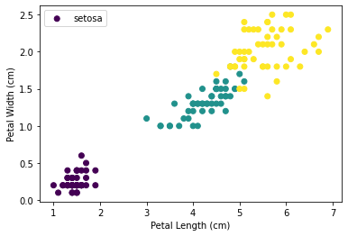

```python
plt.scatter(data_iris.iloc[:,2], data_iris.iloc[:,3], c = iris.target)
plt.xlabel('Petal Length (cm)')
plt.ylabel('Petal Width (cm)')
plt.legend(iris.target_names)
plt.show()
```

#### 3.2.2 Ploting data by differentiating Target values

Here we are ploting each data for two class but now storing the values differently and applying different color for different target values.

- for target in np.unique(iris.target):

  ```
   Selects unique values and make a list out of that values
  ```

- x = [iris.data[i,2] for i in range(len(iris.target)) if iris.target[i]==target]

  ```
  select all the values from column in 2nd index (.i.e. Petal Length ) where column 'target' values matches the condition
  ```

- plt.scatter(x, y, color=['red', 'blue', 'green'][target], label=iris.target_names[target])

  ```
  first we pass the item we want to plot and then we are passing color values for our 3 different targets and assigning names for that values.
  ```

We then give name to labels, provide proper title legend is used to provide discription about the plots and lebels

Note: The values of x and y are ploted 3 times in same plot because of loop for 3 target classes

```
0
1
2
```

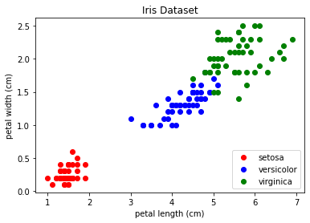

```python
for target in  np.unique(iris.target):
    print(target)
    x = [iris.data[i,2] for i in range(len(iris.target)) if iris.target[i]==target]


    y = [iris.data[i,3] for i in range(len(iris.target)) if iris.target[i]==target]

    plt.scatter(x, y, c=['red', 'blue', 'green'][target], label=iris.target_names[target])


plt.xlabel(iris.feature_names[2])
plt.ylabel(iris.feature_names[3])
plt.title('Iris Dataset')
plt.legend(iris.target_names, loc='lower right')
plt.show()
```

#### 3.2.3 Spliting independent features or X and Y class data

as we know our independent features are upto 4th column index of dataframe we select them and store in a variable

```python
x_data = data_iris.iloc[:,:4]
```

```python
x_data
```

|  | Sepal Length | Sepal Width | Petal Length | Petal Width |
| --- | --- | --- | --- | --- |
| 0 | 5.1 | 3.5 | 1.4 | 0.2 |
| 1 | 4.9 | 3.0 | 1.4 | 0.2 |
| 2 | 4.7 | 3.2 | 1.3 | 0.2 |
| 3 | 4.6 | 3.1 | 1.5 | 0.2 |
| 4 | 5.0 | 3.6 | 1.4 | 0.2 |
| ... | ... | ... | ... | ... |
| 145 | 6.7 | 3.0 | 5.2 | 2.3 |
| 146 | 6.3 | 2.5 | 5.0 | 1.9 |
| 147 | 6.5 | 3.0 | 5.2 | 2.0 |
| 148 | 6.2 | 3.4 | 5.4 | 2.3 |
| 149 | 5.9 | 3.0 | 5.1 | 1.8 |

150 rows × 4 columns

#### 3.2.4 Spliting dependent features or Y data. Data to be predicted

as we know our dependent feature is in our last column index. so we select our last column value

```python
y_data = data_iris.iloc[:,-1]
```

```python
y_data
```

```
0      0
1      0
2      0
3      0
4      0
      ..
145    2
146    2
147    2
148    2
149    2
Name: Target, Length: 150, dtype: int32
```

## 3.3.0 K-Nearest Neighbor (KNN)

K-nearest neighbors (KNN) algorithm uses ‘feature similarity’ to predict the values of new datapoints which further means that the new data point will be assigned a value based on how closely it matches the points in the training set. We can understand its working with the help of following steps −

#### 3.3.1 Steps of KNN

- Step 1 − For implementing any algorithm, we need dataset. So during the first step of KNN, we must load the training as well as test data.
- Step 2 − Next, we need to choose the value of K i.e. the nearest data points. K can be any integer.
- Step 3 − For each point in the test data do the following −
  - 3.1 − Calculate the distance between test data and each row of training data with the help of any of the method namely: Euclidean, Manhattan or Hamming distance. The most commonly used method to calculate distance is Euclidean.
  - 3.2 − Now, based on the distance value, sort them in ascending order.
  - 3.3 − Next, it will choose the top K rows from the sorted array.
  - 3.4 − Now, it will assign a class to the test point based on most frequent class of these rows.
- Step 4 − End

#### 3.3.2 KNN Implementation

First we will import KNeighborsClassifier from sklearn.neighbors pacakages

Then we instanciate the algorithm and pass k value. After that p value will be given to specify which distance algrothim to use.

```
When p = 1, this is equivalent to using manhattan_distance (l1), and euclidean_distance
(l2) for p = 2. For arbitrary p, minkowski_distance (l_p) is used.
```

after that we train with fit function passing the Independent features and dependent features .i.e. X_data and Y_data

```python
from sklearn.neighbors import KNeighborsClassifier

knn = KNeighborsClassifier(n_neighbors = 6, metric = 'minkowski', p = 1)
knn.fit(x_data,  y_data)
```

```
KNeighborsClassifier(n_neighbors=6, p=1)
```

#### 3.3.4 Making new data to make prediction

```python
X_new  = np.array([[5.6, 3.4, 1.4, 0.1]])
```

```python
X_new
```

```
array([[5.6, 3.4, 1.4, 0.1]])
```

#### 3.3.5 Passing those values in the model and running predict function

here, different values represent different classes.

0 = setosa  
1 = versicolor  
2 = verginica

```python
knn.predict(X_new)
```

```
array([0])
```

```python
X_new_2 = np.array([[7.5,4, 5.2, 2]])
```

```python
knn.predict(X_new_2)
```

```
array([2])
```

## 3.4.0 Train Test Spilt

train_test_split is a function in Sklearn model selection for splitting data arrays into two subsets: for training data and for testing data. With this function, you don't need to divide the dataset manually.

By default, Sklearn train_test_split will make random partitions for the two subsets. However, you can also specify a random state for the operation.

```python
from sklearn.model_selection import train_test_split
```

#### 3.4.1 Data Split

Spliting the data into Train, Test for X(independent features) and Y (Dependent features or label to be predected )

First we pass the X_data and Y_data then give trian size which will determine how many percentage of the data to be used as traindata and test data

```python
X_train,X_test,Y_train,Y_test = train_test_split(x_data,y_data,train_size=0.70,random_state=1)
```

#### 3.4.2 Shape of X Train data

```python
X_train.shape
```

```
(105, 4)
```

#### 3.4.3 Shape of X_Test data

```python
X_test.shape
```

```
(45, 4)
```

#### 3.4.4 Shape of Y Train data

```python
Y_train.shape
```

```
(105,)
```

#### 3.4.5 Shape of Y Test data

```python
Y_test.shape
```

```
(45,)
```

#### 3.4.6 Train model

Training the KNN model with with train data

```python
new_knn_model = knn.fit(X_train, Y_train)
```

#### 3.4.7 Printing the model details

```python
new_knn_model
```

```
KNeighborsClassifier(n_neighbors=6, p=1)
```

#### 3.4.8 Pridicting with X_test data

```python
predicted_types = new_knn_model.predict(X_test)
```

#### 3.4.9 Importing metrics for Testing

```python
from sklearn import metrics
```

#### 3.4.10 Testing the accuracy of the model

```python
metrics.accuracy_score(Y_test, predicted_types)
```

```
0.9777777777777777
```

## 3.5.0 Decision Tree Classifier

Decision Tree is a Supervised learning technique that can be used for both classification and Regression problems, but mostly it is preferred for solving Classification problems. It is a tree-structured classifier, where internal nodes represent the features of a dataset, branches represent the decision rules and each leaf node represents the outcome.

In a Decision tree, there are two nodes, which are the Decision Node and Leaf Node. Decision nodes are used to make any decision and have multiple branches, whereas Leaf nodes are the output of those decisions and do not contain any further branches

- Root Node: Root node is from where the decision tree starts. It represents the entire dataset, which further gets divided into two or more homogeneous sets.
- Leaf Node: Leaf nodes are the final output node, and the tree cannot be segregated further after getting a leaf node.
- Splitting: Splitting is the process of dividing the decision node/root node into sub-nodes according to the given conditions.
- Branch/Sub Tree: A tree formed by splitting the tree.
- Pruning: Pruning is the process of removing the unwanted branches from the tree.
- Parent/Child node: The root node of the tree is called the parent node, and other nodes are called the child nodes.

#### 3.5.1 Steps in Decision tree

- Step-1: Begin the tree with the root node, says S, which contains the complete dataset.
- Step-2: Find the best attribute in the dataset using Attribute Selection Measure (ASM).
- Step-3: Divide the S into subsets that contains possible values for the best attributes.
- Step-4: Generate the decision tree node, which contains the best attribute.
- Step-5: Recursively make new decision trees using the subsets of the dataset created in step -3. Continue this process until a stage is reached where you cannot further classify the nodes and called the final node as a leaf node.

#### 3.5.2 Importing necessary pacakage from sklearn

```python
from sklearn.tree import DecisionTreeClassifier
from sklearn.metrics import accuracy_score
```

#### 3.5.3 Model instantiate

```python
model_dt = DecisionTreeClassifier()
```

#### 3.5.2 Training with our training data

```python
model_dt.fit(X_train, Y_train)
```

```
DecisionTreeClassifier()
```

#### 3.5.3 Pridicting the values in our Test data

```python
predict_dt = model_dt.predict(X_test)
```

#### 3.5.4 Testing the accuracy of the model

```python
accuracy_score(Y_test, predict_dt)
```

```
0.9555555555555556
```

#### 3.5.5 Importing cross_validation_score pacakage for model validation

```python
from sklearn.model_selection import cross_val_score
```

#### 3.5.6 Passing the model which we want to validate

```python
scores_DT = cross_val_score(model_dt, X_test, Y_test, cv = 10)
```

```python
scores_DT
```

```
array([1.  , 1.  , 1.  , 0.8 , 1.  , 1.  , 0.75, 1.  , 0.75, 1.  ])
```

# 😊 Thanks for your time 😊

What do you think of this **“Decision Tree and K Nearest Neighbor classification“?**(Appreciation, Suggestions, and Questions are highly appreciated).

[© Ninja Programming Corp](https://www.youtube.com/channel/UCV28m8OOUy4D36rH1T5InRA?sub_confirmation=1) YouTube, 2021.